# Niños

Jhonatan Smith Garcia

2022-11-14

[figure not shown]

Un lindo cerdito

# Base de datos nacimientos hospital

```r
# fn para calcular las raices unitarias y graficas bien chimbita
arroots <- function(object)
{
  if(!("Arima" %in% class(object)) &
     !("ar" %in% class(object)))
    stop("object must be of class Arima or ar")
  if("Arima" %in% class(object))
    parvec <- object$model$phi
  else
    parvec <- object$ar
  if(length(parvec) > 0)
  {
    last.nonzero <- max(which(abs(parvec) > 1e-08))
    if (last.nonzero > 0)
      return(structure(list(
          roots=polyroot(c(1,-parvec[1:last.nonzero])),
          type="AR"),
        class='armaroots'))
  }
  return(structure(list(roots=numeric(0), type="AR"),
    class='armaroots'))
}

# Compute MA roots
maroots <- function(object)
{
  if(!("Arima" %in% class(object)))
    stop("object must be of class Arima")
  parvec <- object$model$theta
  if(length(parvec) > 0)
  {
    last.nonzero <- max(which(abs(parvec) > 1e-08))
    if (last.nonzero > 0)
      return(structure(list(
          roots=polyroot(c(1,parvec[1:last.nonzero])),
          type="MA"),
        class='armaroots'))
  }
  return(structure(list(roots=numeric(0), type="MA"),
    class='armaroots'))
}

plot.armaroots <- function(x, xlab="Real", ylab="Imaginary",
    main=paste("Inverse roots of", x$type,
          "characteristic polynomial"),
    ...)
{
  oldpar <- par(pty='s')
  on.exit(par(oldpar))
  plot(c(-1,1), c(-1,1), xlab=xlab, ylab=ylab,
       type="n", bty="n", xaxt="n", yaxt="n", main=main, ...)
  axis(1, at=c(-1,0,1), line=0.5, tck=-0.025)
  axis(2, at=c(-1,0,1), label=c("-i","0","i"),
    line=0.5, tck=-0.025)
  circx <- seq(-1,1,l=501)
  circy <- sqrt(1-circx^2)
  lines(c(circx,circx), c(circy,-circy), col='gray')
  lines(c(-2,2), c(0,0), col='gray')
  lines(c(0,0), c(-2,2), col='gray')
  if(length(x$roots) > 0)
  {
    inside <- abs(x$roots) > 1
    points(1/x$roots[inside], pch=19, col='black')
    if(sum(!inside) > 0)
      points(1/x$roots[!inside], pch=19, col='red')
  }
}
```

Inicialmente se desea trabajar con un indice. Proporcion de niñas nacidas vs niños nacidos ; es decir:

Hembra/ macho; queremos ver si es igual, menor y si esto tiene una evolucion en el tiempo.

```r
datos <- read.csv("Nacidos_Vivos_en_Hospital_Manuel_Uribe_Angel.csv")
datos$FECHA.NACIMIENTO <- gsub(" \\d+:\\d+:\\d+ .*", "", datos$FECHA.NACIMIENTO)
datos$FECHA.NACIMIENTO <- as.Date(datos$FECHA.NACIMIENTO, format = "%m/%d/%Y")
```

```r
datos <- datos %>%  mutate(Anio = year(FECHA.NACIMIENTO), semana = week(FECHA.NACIMIENTO)) %>%
  group_by(Anio, semana) %>%
  summarise(ratio = sum(SEXO != "MASCULINO")/sum(SEXO == "MASCULINO"))
lambda <- forecast::BoxCox.lambda(datos$ratio)
datos$ratio <- forecast::BoxCox(datos$ratio, lambda)
```

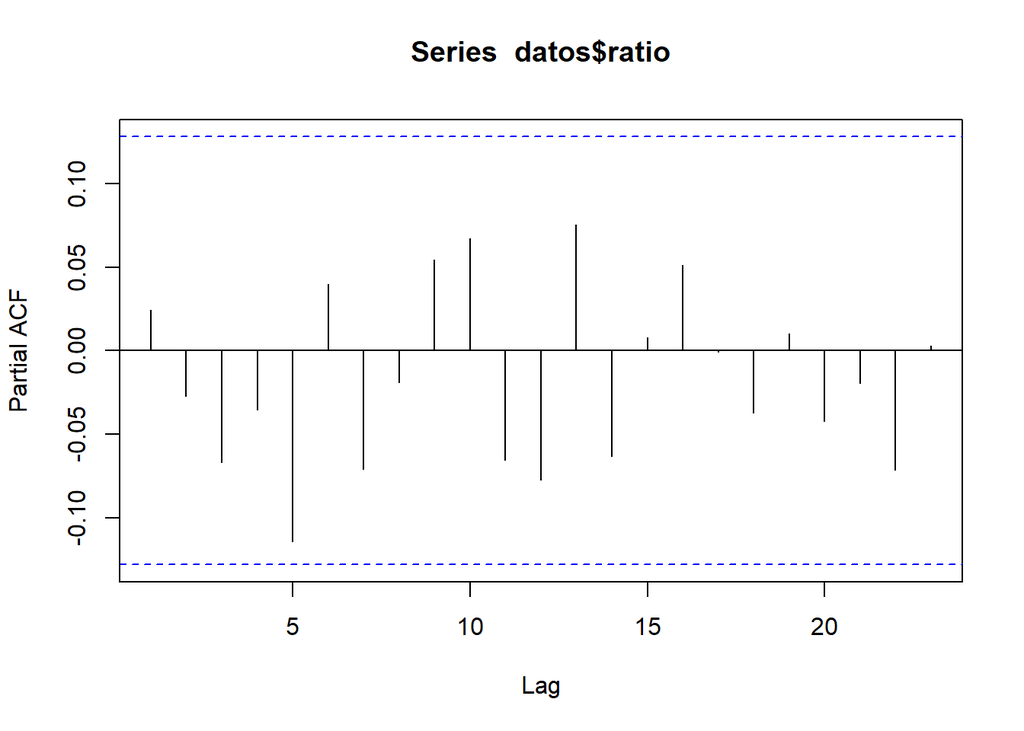

```r
pacf(datos$ratio)
```

Empezamos mal…

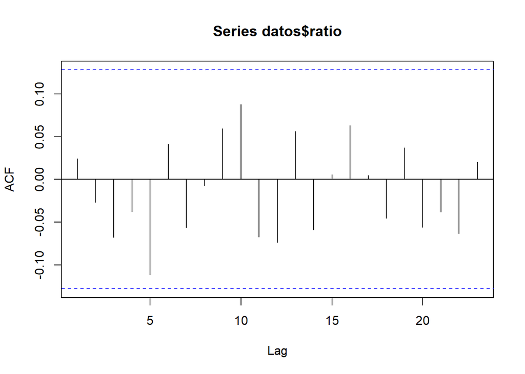

```r
acf(datos$ratio)
```

Y terminamos pior. Valemos verga.

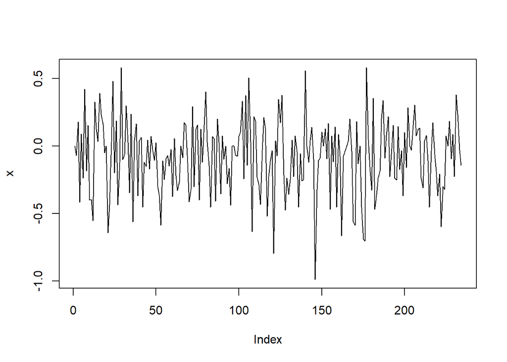

```r
x = datos$ratio
plot(x, type = "l")
```

Ombe pues bonita si se ve peeero… Y entonces?

```r
mod <- forecast::auto.arima(datos$ratio)
summary(mod)
```

```
## Series: datos$ratio
## ARIMA(0,0,0) with non-zero mean
##
## Coefficients:
##          mean
##       -0.0792
## s.e.   0.0176
##
## sigma^2 = 0.07244:  log likelihood = -24.4
## AIC=52.81   AICc=52.86   BIC=59.72
##
## Training set error measures:
##                         ME      RMSE       MAE  MPE MAPE      MASE       ACF1
## Training set -1.078795e-16 0.2685679 0.2123661 -Inf  Inf 0.7034017 0.02433439
```

Como dijo aquella figura de la tv mexicana; ‘Lo sospeché desde un principio’

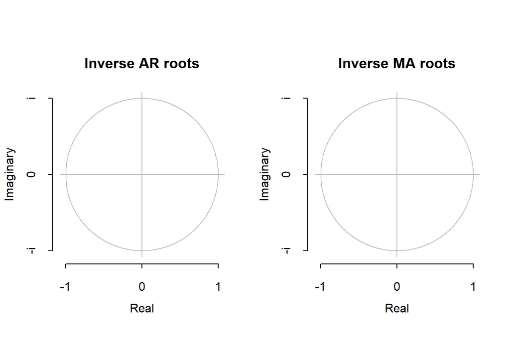

```r
library(forecast)
fit <- mod
par(mfrow=c(1,2))
plot(arroots(fit),main="Inverse AR roots")
plot(maroots(fit),main="Inverse MA roots")
```

Basicamente vale monda este modelo. No el modelo, el problema

¿Que pasó con las raíces? # Maso, oh tu que todo lo sabes. Iluminad a este pobre mortal, pues la luz de la esperanza se escapa ante cada linea de codigo que escribe.

Hipotesis: La naturaleza del problema no responde a un analisis de series temporales. La proporcion de nacimientos de niños vs niñas no varia en el tiempo; no es un dato temporal.

Nota para smith del futuro: Basicamente, piense en la teoria antes de perder toda la tarde haciendo estas pendejadas buscando soluciones rebuscadas. KISS

## Niños… Oh, si; niños.

```r
# Probemos con una bd de conteo de niños.
datos <- read.csv("Nacidos_Vivos_en_Hospital_Manuel_Uribe_Angel.csv")
datos$FECHA.NACIMIENTO <- gsub(" \\d+:\\d+:\\d+ .*", "", datos$FECHA.NACIMIENTO)
datos$FECHA.NACIMIENTO <- as.Date(datos$FECHA.NACIMIENTO, format = "%m/%d/%Y")
# otra veez, porque soy imbecil

datos.total.kids = datos[order(datos$FECHA.NACIMIENTO),]

datos.total.kids = datos.total.kids %>% mutate(Anio = year(FECHA.NACIMIENTO), semana = week(FECHA.NACIMIENTO)) %>%group_by(Anio, semana) %>%
  summarise(total.kids = sum(SEXO == 'MASCULINO')+sum(SEXO !='MASCULINO')  )
#Miremos que salió
```

Para esta base de datos, estudiaremos un conjunto de información del sector salud, para dictaminar conclusiones acerca del análisis en cuestión de series temporales que podamos hacer para estos datos, se tomara información del Hospital Manuel Uribe Ángel, el cual está ubicado en el departamento de Antioquia, específicamente en el municipio de envigado; la fecha de emisión de la base de datos fue el 2019-10-08 y esta se actualiza de manera trimestral, los datos que residen en esta base apuntan hacia la caracterización de los nacimientos que hubo en este hospital desde el 2018, entre los datos hay información como el sexo del niño, el departamento, el municipio, el área de nacimiento, el peso en gramos, la talla de nacimiento, la fecha de nacimiento y demás.

```r
datos %>% head() # Hay muchas variables.
```

```
##   DEPARTAMENTO MUNICIPIO    AREA.NACIMIENTO      SEXO PESO..Gramos.
## 1    ANTIOQUIA  ENVIGADO CABECERA MUNICIPAL MASCULINO          2085
## 2    ANTIOQUIA  ENVIGADO CABECERA MUNICIPAL  FEMENINO          3000
## 3    ANTIOQUIA  ENVIGADO CABECERA MUNICIPAL MASCULINO          2905
## 4    ANTIOQUIA  ENVIGADO CABECERA MUNICIPAL  FEMENINO          3700
## 5    ANTIOQUIA  ENVIGADO CABECERA MUNICIPAL  FEMENINO          3130
## 6    ANTIOQUIA  ENVIGADO CABECERA MUNICIPAL MASCULINO          3830
##   TALLA..Centímetros. FECHA.NACIMIENTO TIEMPO.DE.GESTACIÓN
## 1                  45       2022-05-06                  37
## 2                  47       2022-05-06                  37
## 3                  50       2022-05-07                  39
## 4                  50       2022-05-07                  40
## 5                  49       2022-05-07                  39
## 6                  54       2021-10-01                  40
##   NÚMERO.CONSULTAS.PRENATALES    TIPO.PARTO MULTIPLICIDAD.EMBARAZO
```

[output cut: 62 more lines]

*Podriamos dictaminar entonces, algun tipo de estacionaldiad en los datos y nacimientos? ? Les leemos el Tarot con un modelo ARIMA?*

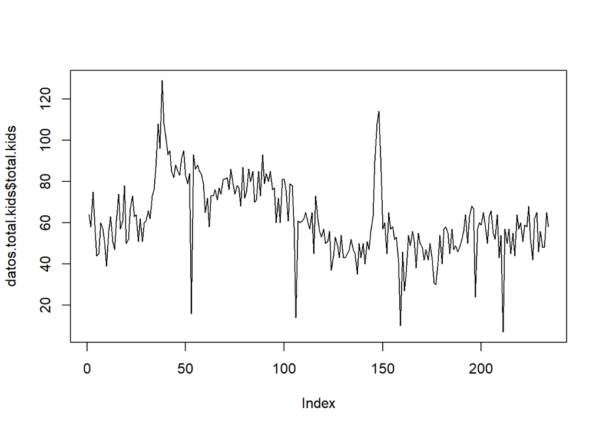

```r
plot(datos.total.kids$total.kids, type = 'l') # se ve mas chimbita
```

Vemos en la gráfica de la serie que hay periodos donde la serie de tiempo presenta tendencia creciente y que hay ciertos picos y valles, de cierta manera podríamos decir que al final de serie la predominancia es una tendencia bajista, a primera vista no es evidente alguna estacionalidad y se sospecha que la serie por su componente de tendencia necesitara una diferenciación.

```r
b=auto.arima(datos.total.kids$total.kids) # tiene mas sentido
b
```

```
## Series: datos.total.kids$total.kids
## ARIMA(1,1,2)
##
## Coefficients:
##          ar1      ma1     ma2
##       0.8278  -1.4003  0.4234
## s.e.  0.1064   0.1326  0.1124
##
## sigma^2 = 164.3:  log likelihood = -923.88
## AIC=1855.75   AICc=1855.93   BIC=1869.56
```

Como era de esperarse, la serie requiere una diferenciación, además tiene ordenes p y q de 1 y 2 respectivamente.

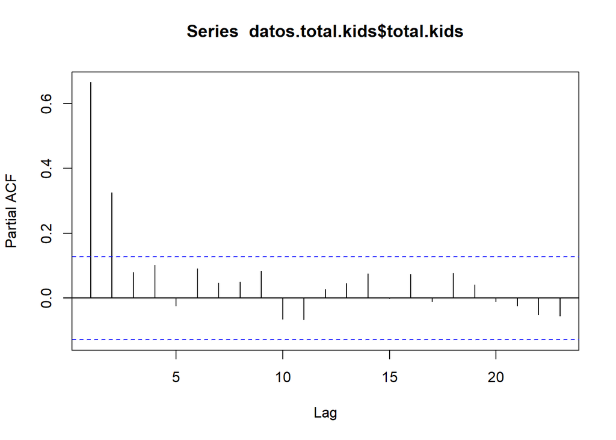

```r
pacf(datos.total.kids$total.kids)
```

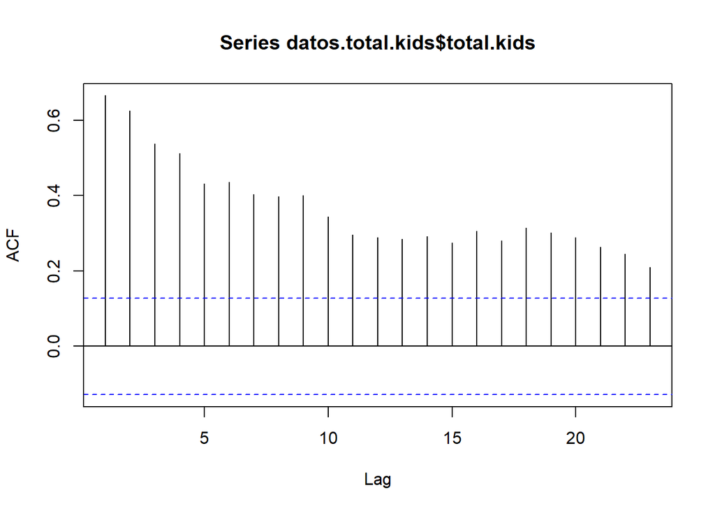

```r
acf(datos.total.kids$total.kids)
```

Analizando la acf, vemos que esta tiene un decaimiento lento, que como vimos anteriormente se puede deber a la presencia de tendencia; esto confirma la necesidad de una diferenciación para buscar la estacionariedad en la serie.

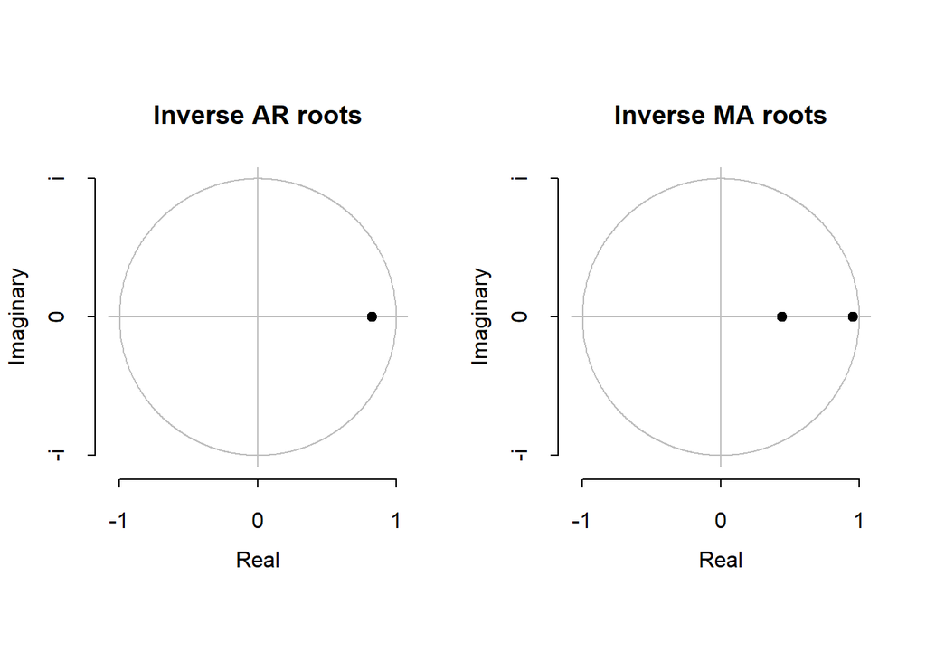

```r
fit <- b
par(mfrow=c(1,2))
plot(arroots(fit),main="Inverse AR roots")
plot(maroots(fit),main="Inverse MA roots")
```

remember: (And as a consequence, the solution of a homogeneous autoregressive difference equation is stable if all roots of its characteristic polynomials are inside the unit circle, or equivalently, the roots of its inverse characteristic polynomial are outside of the unit circle.)

Según la prueba de las raíces unitarias y analizando sus inversos para poder hacer una gráfica ilustrativa como se ve en la propuesta anterior, vemos que este modelo es estacionario e invertible, lo cual nos indica que el modelo tiene validez y que podemos proseguir con los análisis pertinentes.